# CMSC320 Final Tutorial

Austin Kim, James Ho

Héctor Corrada Bravo

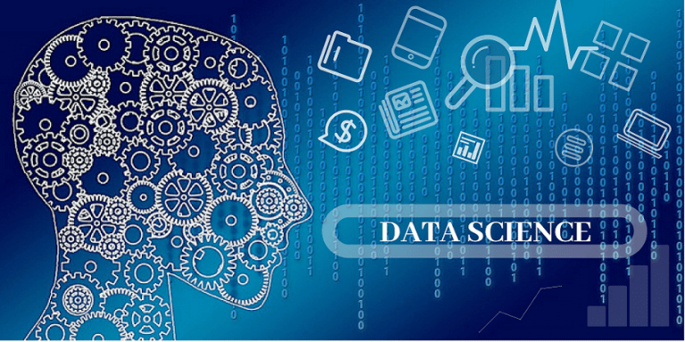

# Introduction

##### This tutorial was made with the purpose of making discoveries by analyzing students’ academic AND social statistics.

##### We will be analyzing a dataset on students in secondary school, taking a math class. Our data contains a lot of interesting social, gender, and study habit information about students.

##### We can use it to make a lot of compelling insights and determine the best predictors of students’ final grades.

# The Dataset

##### The dataset we will analyze and extrapolate from is titled “Student Alcohol Consumption.” We obtained this dataset from the Kaggle Database that contains a variety of datasets for popular use.

##### You can download the particular dataset we used [here](https://www.kaggle.com/uciml/student-alcohol-consumption/downloads/student-alcohol-consumption.zip/2#student-por.csv).

##### If you plan on working on this dataset on your own or following step by step with this tutorial, make sure you unzip the csv files into the same working directory that you will be writing your R code in!

## Content of the Dataset

### Attributes

1. **school**: student’s school (binary: ‘GP’ - Gabriel Pereira or ‘MS’ - Mousinho da Silveira)
2. **sex**: student’s sex (binary: ‘F’ - female or ‘M’ - male)
3. **age**: student’s age (numeric: from 15 to 22)
4. **address**: student’s home address type (binary: ‘U’ - urban or ‘R’ - rural)
5. **famsize**: family size (binary: ‘LE3’ - less or equal to 3 or ‘GT3’ - greater than 3)
6. **Pstatus**: parent’s cohabitation status (binary: ‘T’ - living together or ‘A’ - apart)
7. **Medu**: mother’s education (numeric: 0-none, 1-primary education(4th grade), 2 - 5th to 9th grade, 3 - secondary-education or 4 - higher-education)
8. **Fedu**: father’s education (numeric: 0-none, 1 - primary education (4th grade), 2 - 5th to 9th grade, 3 - secondary education or 4 - higher education)
9. **Mjob**: mother’s job (nominal: ‘teacher’, ‘health’ care related, civil ‘services’ (e.g. administrative or police), ‘at_home’ or ‘other’)
10. **Fjob**: father’s job (nominal: ‘teacher’, ‘health’ care related, civil ‘services’ (e.g. administrative or police), ‘at_home’ or ‘other’)
11. **reason**: reason to choose this school (nominal: close to ‘home’, school ‘reputation’, ‘course’ preference or ‘other’)
12. **guardian**: student’s guardian (nominal: ‘mother’, ‘father’ or ‘other’)
13. **traveltime**: home to school travel time (numeric: 1 - <15 min., 2 - 15 to 30 min., 3 - 30 min. to 1 hour, or 4 - >1 hour)
14. **studytime**: weekly study time (numeric: 1 - <2 hours, 2 - 2 to 5 hours, 3 - 5 to 10 hours, or 4 - >10 hours)
15. **failures**: number of past class failures (numeric: n if 1<=n<3, else 4)
16. **schoolsup**: extra educational support (binary: yes or no)
17. **famsup**: family educational support (binary: yes or no)
18. **paid**: extra paid classes within the course subject (Math or Portuguese) (binary: yes or no)
19. **activities**: extra-curricular activities (binary: yes or no)
20. **nursery**: attended nursery school (binary: yes or no)
21. **higher**: wants to take higher education (binary: yes or no)
22. **internet**: Internet access at home (binary: yes or no)
23. **romantic**: with a romantic relationship (binary: yes or no)
24. **famrel**: quality of family relationships (numeric: from 1 - very bad to 5 - excellent)
25. **freetime**: free time after school (numeric: from 1 - very low to 5 - very high)
26. **goout**: going out with friends (numeric: from 1 - very low to 5 - very high)
27. **Dalc**: workday alcohol consumption (numeric: from 1 - very low to 5 - very high)
28. **Walc**: weekend alcohol consumption (numeric: from 1 - very low to 5 - very high)
29. **health**: current health status (numeric: from 1 - very bad to 5 - very good)
30. **absences**: number of school absences (numeric: from 0 to 93)

These grades are related with the course subject, Math or Portuguese:

- G1: first period grade (numeric: from 0 to 20)
- G2: second period grade (numeric: from 0 to 20)
- G3: final grade (numeric: from 0 to 20, output target)

# Tutorial Chapters

| **Chapter** | **Description** |
| --- | --- |
| **1** | Average difference in grades between Males and Females |
| **2** | Impact of hours studied on academic performance |
| **3** | Using Linear Regression to make estimates on final grades |
| **4** | Analysis of models Residuals |
| **5** | Average comparison: Desire for higher education -> impact on student grades |
| **6** | Multivariate plotting: Analysis of female students and Mother’s education and occupation |
| **7** | Academic performance and romantic relationships |
| **8** | Plot of alcohol consumption and academic success |
| **9** | Student alcohol consumption and family relationships |
| **10** | Multivariable linear models, testing, and variance |
| **11** | MultiFaceted graph |
| **12** | Machine Learning LDA: determining students’ desire to pursue higher education |
| —> 12.1 | …… Class means and squared error |
| —> 12.2 | …… Sum of squared errors |
| —> 12.3 | …… Variance |
| —> 12.4 | …… Predictions |
| —> 12.5 | …… Truth table |
| —> 12.6 | …… Error rate |
| —> 12.7 | …… ROC |
| —> 12.8 | …… AUROC |
| —> 12.9 | …… Precision Recall |

# Data Management and Preparation

### Loading the data set

```r
student_data <- read_csv("student-mat.csv")
```

Here is a summary of our data

```r
student_data
```

```
## # A tibble: 395 x 33
##    school sex     age address famsize Pstatus  Medu  Fedu Mjob  Fjob
##    <chr>  <chr> <dbl> <chr>   <chr>   <chr>   <dbl> <dbl> <chr> <chr>
##  1 GP     F        18 U       GT3     A           4     4 at_h~ teac~
##  2 GP     F        17 U       GT3     T           1     1 at_h~ other
##  3 GP     F        15 U       LE3     T           1     1 at_h~ other
##  4 GP     F        15 U       GT3     T           4     2 heal~ serv~
##  5 GP     F        16 U       GT3     T           3     3 other other
##  6 GP     M        16 U       LE3     T           4     3 serv~ other
##  7 GP     M        16 U       LE3     T           2     2 other other
##  8 GP     F        17 U       GT3     A           4     4 other teac~
##  9 GP     M        15 U       LE3     A           3     2 serv~ other
## 10 GP     M        15 U       GT3     T           3     4 other other
## # ... with 385 more rows, and 23 more variables: reason <chr>,
## #   guardian <chr>, traveltime <dbl>, studytime <dbl>, failures <dbl>,
## #   schoolsup <chr>, famsup <chr>, paid <chr>, activities <chr>,
## #   nursery <chr>, higher <chr>, internet <chr>, romantic <chr>,
## #   famrel <dbl>, freetime <dbl>, goout <dbl>, Dalc <dbl>, Walc <dbl>,
## #   health <dbl>, absences <dbl>, G1 <dbl>, G2 <dbl>, G3 <dbl>
```

## 1. Average Difference in grades between males and females

#### Lets see the average final grade difference between males and females

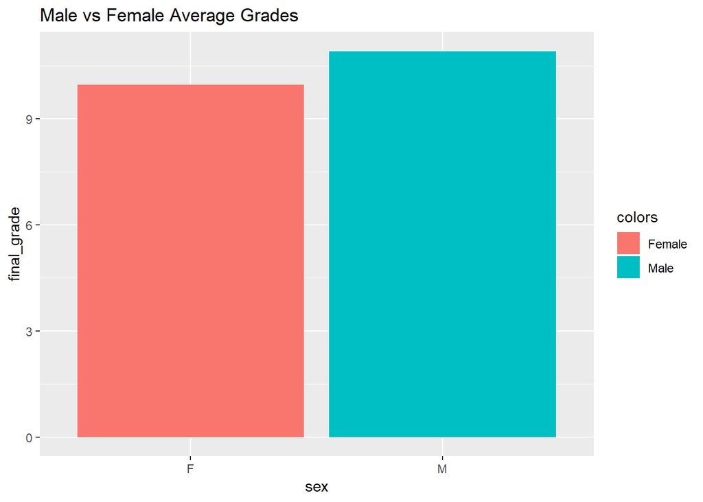

```r
colors = c("Female", "Male")
student_data %>%
  group_by(sex) %>%
  summarise(final_grade=mean(G3)) %>%
  ggplot(mapping=aes(y=final_grade, x=sex, fill = colors)) +
    geom_bar(stat="identity") +
  labs(title = "Male vs Female Average Grades")
```

## 2. Impact of hours studied on academic performance

#### Next, let’s see how grades are affected by a student’s amount of hours spent studying per week.

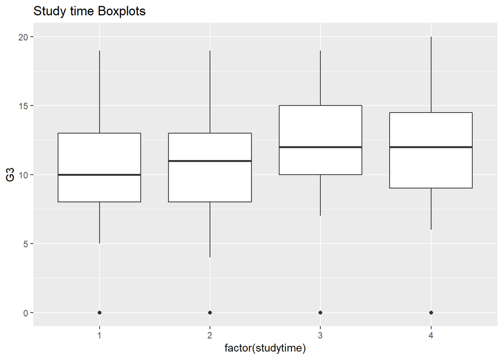

```r
student_data %>%
  ggplot(mapping=aes(y=G3, x=factor(studytime))) +
    geom_boxplot() +
  labs(title = "Study time Boxplots")
```

## 3. Using Linear Regression to make estimates on final grades

#### We construct a linear regression model of studytime relation with the average grade for each time.

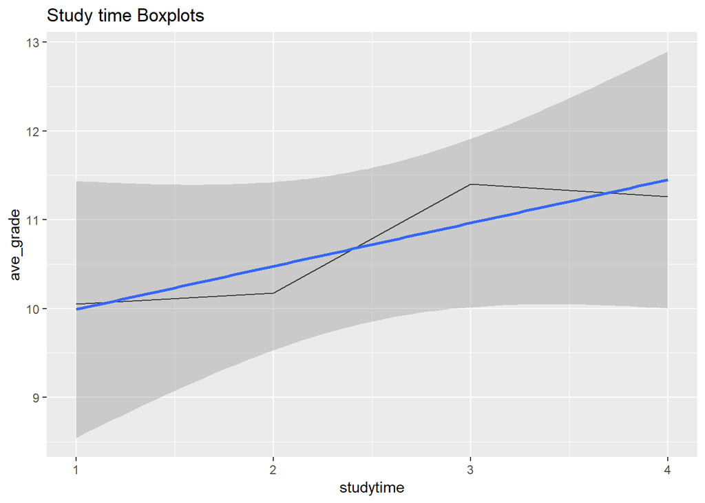

```r
student_data %>%
  group_by(studytime) %>%
  summarise(ave_grade=mean(G3)) %>%
  ggplot(mapping=aes(y=ave_grade, x=studytime)) +
    geom_line() +
    geom_smooth(method=lm) +
  labs(title = "Study time Boxplots")
```

```r
ave_grades_data <- student_data %>%
  group_by(studytime) %>%
  summarise(ave_grade=mean(G3))
fit <- lm(ave_grade~studytime, data=ave_grades_data)
broom::tidy(fit)
```

```
## # A tibble: 2 x 5
##   term        estimate std.error statistic p.value
##   <chr>          <dbl>     <dbl>     <dbl>   <dbl>
## 1 (Intercept)    9.50      0.492     19.3  0.00267
## 2 studytime      0.486     0.180      2.70 0.114
```

## 4. Analysis of models Residuals

#### Let’s now make a residuals vs. study hours graph for the linear model we made above.

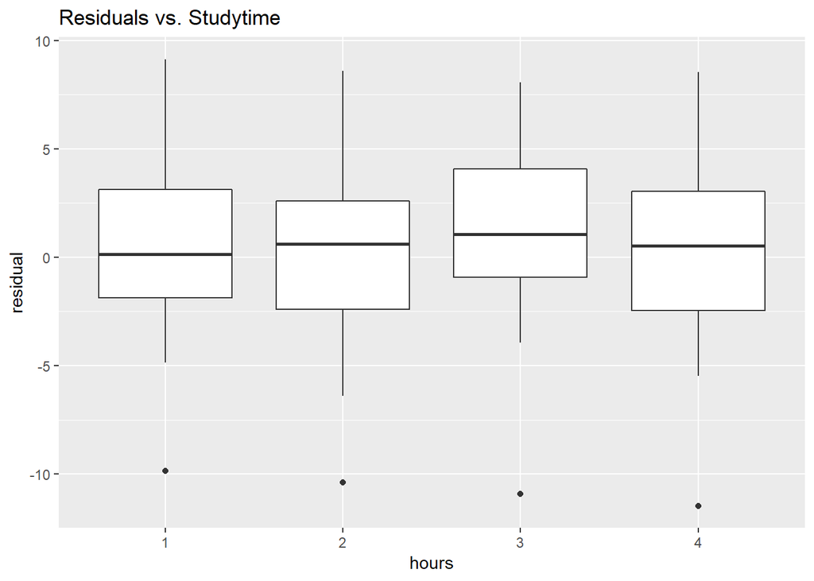

```r
res_fit <- lm(G3~studytime, data=student_data)
augmented_stat <- res_fit %>%
  augment()
augmented_stat %>%
  ggplot(aes(x=factor(studytime),y=.resid)) +
    labs(title = "Residuals vs. Studytime", x="hours", y="residual") +
    geom_boxplot()
```

## 5. Average comparison: Desire for higher education -> impact on student grades

#### Does a student’s desire on going to college have a significant relationship with a student’s grades? Or does future plans of going to college not have any effect on a students grades? We will check this by finding the average grade of students on both sides of college preference.

```r
student_data %>%
  group_by(higher) %>%
  summarise(mean(G3))
```

```
## # A tibble: 2 x 2
##   higher `mean(G3)`
##   <chr>       <dbl>
## 1 no            6.8
## 2 yes          10.6
```

## 6. Multivariate plotting: Analysis of female students and Mother’s education and occupation

#### Next, let’s inquire whether or not a student’s mother went to college and has a job has any effect on a female student’s grades.

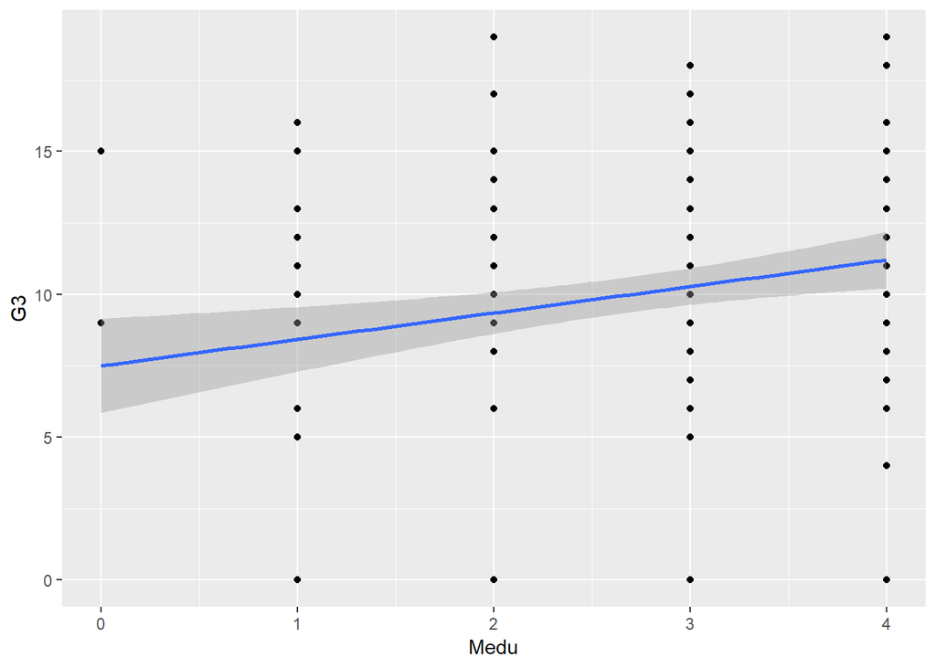

```r
student_data %>%
  filter(sex=="F") %>%
  ggplot(aes(x=Medu, y=G3)) +
    geom_point() +
    geom_smooth(method=lm)
```

We create a graph that compares female students’ mother’s education level with the grade obtained. The x-axis (Medu) represents the mother’s education (0: none, 1: primary education(4th grade), 2: 5th to 9th grade, 3: secondary-education or 4: higher-education). There is an upward trend which means that there is a positive relationship although it is very slight.

## 7. Academic performance and romantic relationships

#### Does a girl in a relationship do better at school compared to a boy in a relationship in school? Analyzing this would be interesting because it might give us insight on which sex is more effected in a negative or postive way, academically, when in a romantic relationship.

```r
student_data %>%
  group_by(romantic, sex) %>%
  summarise(grade=mean(G3))
```

```
## # A tibble: 4 x 3
## # Groups:   romantic [2]
##   romantic sex   grade
##   <chr>    <chr> <dbl>
## 1 no       F     10.6
## 2 no       M     11.1
## 3 yes      F      9.01
## 4 yes      M     10.4
```

- Our findings tell us that male and females in a relationship get worse grades on average compared to non-romantic students. This makes sense because students in relationship may be distracted by their boyfriend/girlfriend more than they are focused on school. Our finding also shows us that while cuffed males in a relationship do about 0.69 points worse than single boiis, females do 1.54 points worse in school when they are in a romantic relationship. Thus we can hypothesize that girls are more affected academically by romance than boys are. Ah… What young love can do…

## 8. Plot of alcohol consumption and academic success

#### How does alcohol consumption relate to a student’s grades? Can you be an alcoholic and still be great at school? Lets find the average grades based on alcohol consumption of students. First lets sum up the total alcohol a student consumes per week by adding the week day and weekend alcohol consumptions together. We will use this sum in our analysis.

```r
student_data <- student_data %>%
  mutate(total_alc = Dalc + Walc)
```

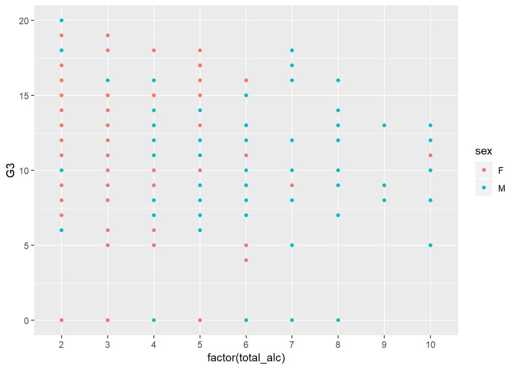

```r
student_data %>%
  ggplot(mapping=aes(y=G3, x=factor(total_alc), color=sex)) +
    geom_point()
```

```r
  labs(title = "Alcoholic students!")
```

[output not shown]

## 9. Student alcohol consumption and family relationships

#### Considering that alcohol has an affect on academic performance, let us ask how does family relationship status relate to a students alcohol consumption. Doing this may lead us to the cause of alochol consumption that is ruining grades.

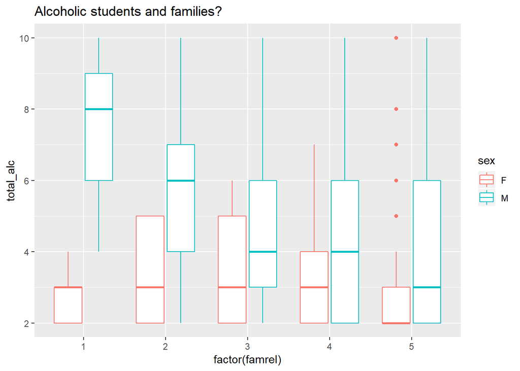

```r
student_data %>%
  ggplot(mapping=aes(y=total_alc, x=factor(famrel), color=sex)) +
    geom_boxplot() +
  labs(title = "Alcoholic students and families?")
```

This graph is quite meaty. Firstly, we see that males drink most when they have bad family relationships and they drink much less as their family relationship improves. On the other hand, girls’ Alc consumption is constant regardless of their family relationship. We can conclude this analysis by saying that bad family relationships will make male students get worse grades because they will likely drink more alcohol which causes bad grades.

## 10. Multivariable linear models, testing, and variance

#### Now to confirm this speculation that family relationship status has an affect on students grades through alcohol, let us test this with analysis.

```r
fit1 <- lm(G3~total_alc*famrel, data = student_data)
fit2 <- lm(total_alc~famrel, data = student_data)
broom::tidy(fit1)
```

```
## # A tibble: 4 x 5
##   term             estimate std.error statistic p.value
##   <chr>               <dbl>     <dbl>     <dbl>   <dbl>
## 1 (Intercept)         6.61      2.18       3.03 0.00259
## 2 total_alc           0.703     0.467      1.50 0.133
## 3 famrel              1.08      0.531      2.03 0.0426
## 4 total_alc:famrel   -0.212     0.116     -1.83 0.0686
```

```r
broom::tidy(fit2)
```

```
## # A tibble: 2 x 5
##   term        estimate std.error statistic  p.value
##   <chr>          <dbl>     <dbl>     <dbl>    <dbl>
## 1 (Intercept)    4.72      0.449     10.5  6.08e-23
## 2 famrel        -0.240     0.111     -2.16 3.12e- 2
```

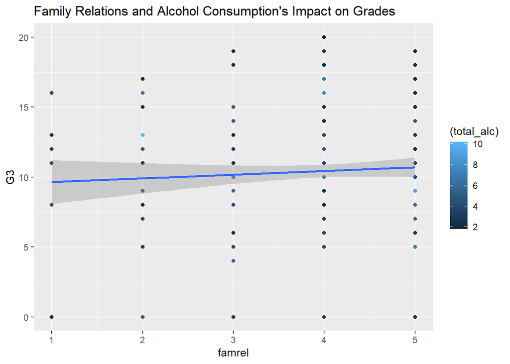

```r
student_data %>%
  ggplot(aes(x=famrel, y=G3, color=(total_alc))) +
    geom_point() +
    geom_smooth(method=lm) +
  labs(title = "Family Relations and Alcohol Consumption's Impact on Grades")
```

Lets do an analysis of variance using Anova:

- [anova guide](http://www.sthda.com/english/wiki/one-way-anova-test-in-r)
- The link is a guide on anova functions if you are curious in other ways to use it.

```r
 anova(fit1, fit2, test = "F")
```

```
## Analysis of Variance Table
##
## Response: G3
##                   Df Sum Sq Mean Sq F value  Pr(>F)
## total_alc          1   28.1  28.055  1.3451 0.24685
## famrel             1   17.0  16.982  0.8142 0.36744
## total_alc:famrel   1   69.5  69.531  3.3336 0.06864 .
## Residuals        391 8155.3  20.858
## ---
## Signif. codes:  0 '***' 0.001 '**' 0.01 '*' 0.05 '.' 0.1 ' ' 1
```

## 11. MultiFaceted graph

#### Lets make a multifaceted plot of our students’ sex, studytime, age, and final grade in order to make observations that include all these factors.

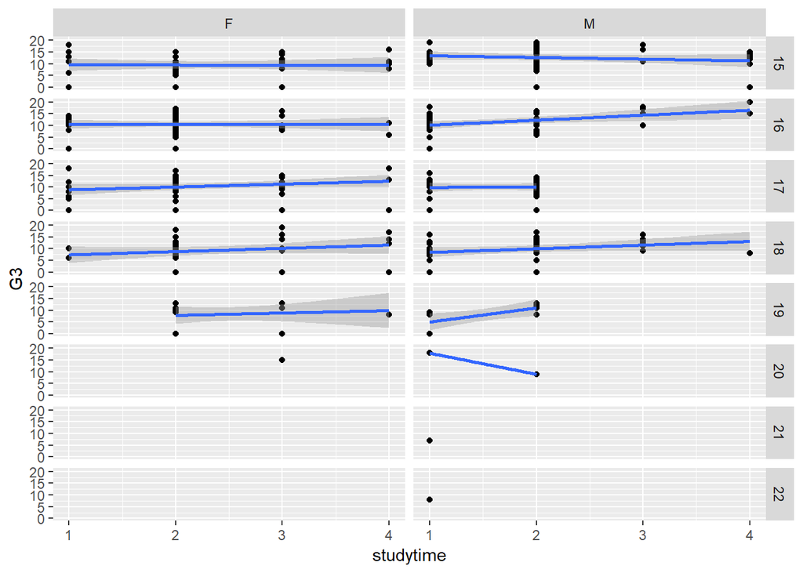

```r
student_data %>%
  ggplot(aes(x=studytime, y=G3)) +
  facet_grid(age~sex) +
  geom_point() +
  geom_smooth(method=lm)
```

## 12. Machine Learning LDA: determining students’ desire to pursue higher education

#### 12.1. Class means and squared error

Compute class means and squared error based on class mean.

```r
lda_stats <- student_data %>%
  group_by(higher) %>%
  mutate(class_mean=mean(studytime),
         squared_error=(studytime-class_mean)^2)
```

#### 12.2. Sum of squared errors

Let’s compute the class sizes and sum of squared errors.

```r
lda_stats <- lda_stats %>%
  summarize(class_mean=first(class_mean),
            class_size=n(),
            sum_squares=sum(squared_error))
```

#### 12.3. Variance

Compute class prior and variance (note same variance for both classes).

```r
lda_stats <- lda_stats %>%
  mutate(class_prior=class_size/sum(class_size),
         sigma2=sum(sum_squares) / (sum(class_size) - 2)) %>%
  dplyr::select(higher, class_mean, class_prior, sigma2)
lda_stats
```

```
## # A tibble: 2 x 4
##   higher class_mean class_prior sigma2
##   <chr>       <dbl>       <dbl>  <dbl>
## 1 no           1.4       0.0506  0.684
## 2 yes          2.07      0.949   0.684
```

- How do we predict with LDA? Predict Yes if P(Y=1 |X) > P(Y=0 |X), no otherwise.
- But how do we solve P(Y=1 |X) > P(Y=0 |X). There is a formula but we will do it in r code.

```r
lda_log_ratio <- function(studytime, lda_stats) {
  n <- length(studytime)

  # subtract class mean
  centered_studytime <- rep(studytime, 2) - rep(lda_stats$class_mean, each=n)

  # scale by standard deviation
  scaled_studytime <- centered_studytime / sqrt(lda_stats$sigma2[1])

  # compute log normal density and add log class prior
  lprobs <- dnorm(scaled_studytime, log=TRUE) + log(rep(lda_stats$class_prior, each=n))

  # compute log ratio of class probabilities
  lprobs <- matrix(lprobs, nc=2)
  colnames(lprobs) <- lda_stats$higher
  lprobs[,"yes"] - lprobs[,"no"]
}
```

#### 12.4. Predictions

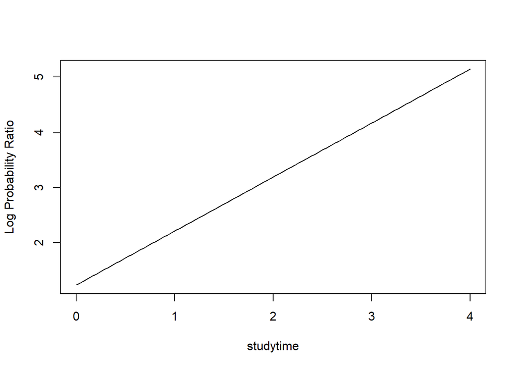

```r
testStudytime <- seq(0, 4, len=100)
plot(testStudytime, lda_log_ratio(testStudytime, lda_stats),
     type="l", xlab="studytime", ylab="Log Probability Ratio", cex=1.4)
```

Now, Lets evaluate how well our classifier performs. We made some predictions earlier, but how true are those predictions? How good is our model? We can find out by measuring the error rate of the classifier. In other words, the amount of mistakes our classifier makes when it predicts a students desire for pursuing higher education based on how much they study.

In the following we will print out a table that displays the truth table of our models predictions.

#### 12.5. Truth Table

```r
library(MASS)
lda_fit <- lda(higher ~ studytime, data=student_data)
lda_pred <- predict(lda_fit, data=student_data)
print(table(predicted=lda_pred$class, observed=student_data$higher))
```

```
##          observed
## predicted  no yes
##       no    0   0
##       yes  20 375
```

This table shows that our model never predicts any student to not be pursuing a higher education level. But, it correctly predicted 375 students to be pursuing higher education but predicted 20 incorectly.

To calculate the error rate, we compare how many predictions were not the same as the answer, and find the mean.

#### 12.6. Error Rate

```r
# error rate
mean(student_data$higher != lda_pred$class) * 100
```

```
## [1] 5.063291
```

We can illustrate how well our model works with the false positive rate and the true positive rate by plotting a ROC Curve.  
A receiver operating characteristic curve, or ROC curve, is a graphical plot that illustrates the diagnostic ability of a binary classifier system as its discrimination threshold is varied. The ROC curve is created by plotting the true positive rate against the false positive rate at various threshold settings.

#### 12.7. ROC

```r
#install.packages("ROCR")
library(ROCR)
```

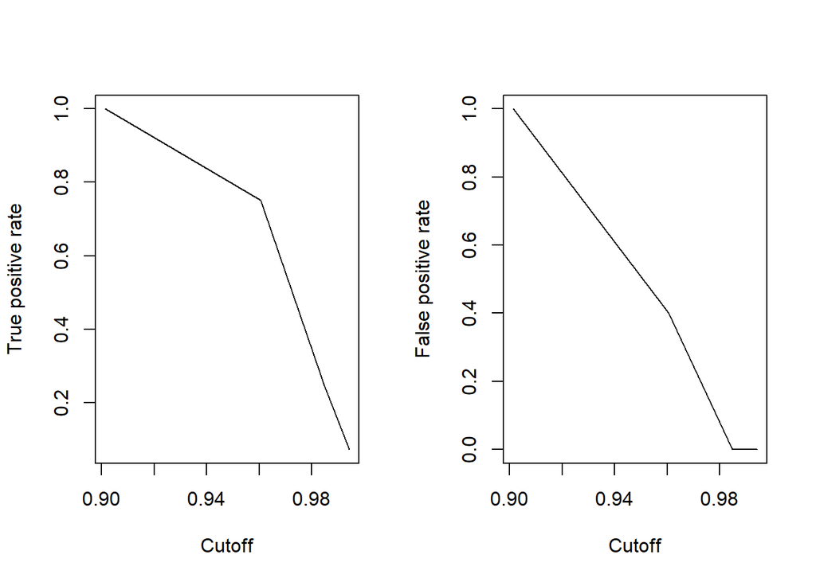

```r
pred <- prediction(lda_pred$posterior[,"yes"], student_data$higher)
layout(cbind(1,2))
plot(performance(pred, "tpr"))
plot(performance(pred, "fpr"))
```

We can also plot a AUC-ROC for more information on our model. AUC represents degree or measure of separability. It tells how much this model is capable of distinguishing between classes/higher-education-pursuit.

#### 12.8. AUROC

```r
full_lda <- lda(higher~., data=student_data)
full_lda_preds <- predict(full_lda, student_data)

pred_list <- list(
  studytime_lda = lda_pred$posterior[,"yes"],
  full_lda = full_lda_preds$posterior[,"yes"],
  dummy = rep(0, nrow(student_data)))

pred_objs <- lapply(pred_list,
  prediction, student_data$higher)

aucs <- sapply(pred_objs,
  function(x) unlist(
    performance(x, "auc")@y.values))

roc_objs <- lapply(pred_objs,
  performance, "tpr", "fpr")
```

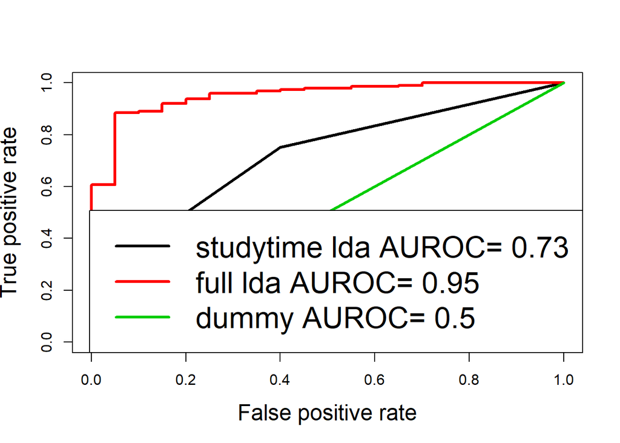

```r
for (i in seq(along=roc_objs)) {
  plot(roc_objs[[i]], add = i != 1, col=i,
       lwd=3, cex.lab=1.5)
}
legend("bottomright",
       legend=paste(gsub("_", " ", names(pred_list)), "AUROC=",round(aucs, 2)),
       col=1:3, lwd=3, cex=2)
```

Now let’s show the precision recall of this LDA. A precision-recall curve shows the relationship between precision (= positive predictive value) and recall (= sensitivity) for every possible cut-off. The PRC is a graph with:

- The x-axis showing recall (= sensitivity = TP / (TP + FN))
- The y-axis showing precision (= positive predictive value = TP / (TP + FP))

#### 12.9. Precision Recall

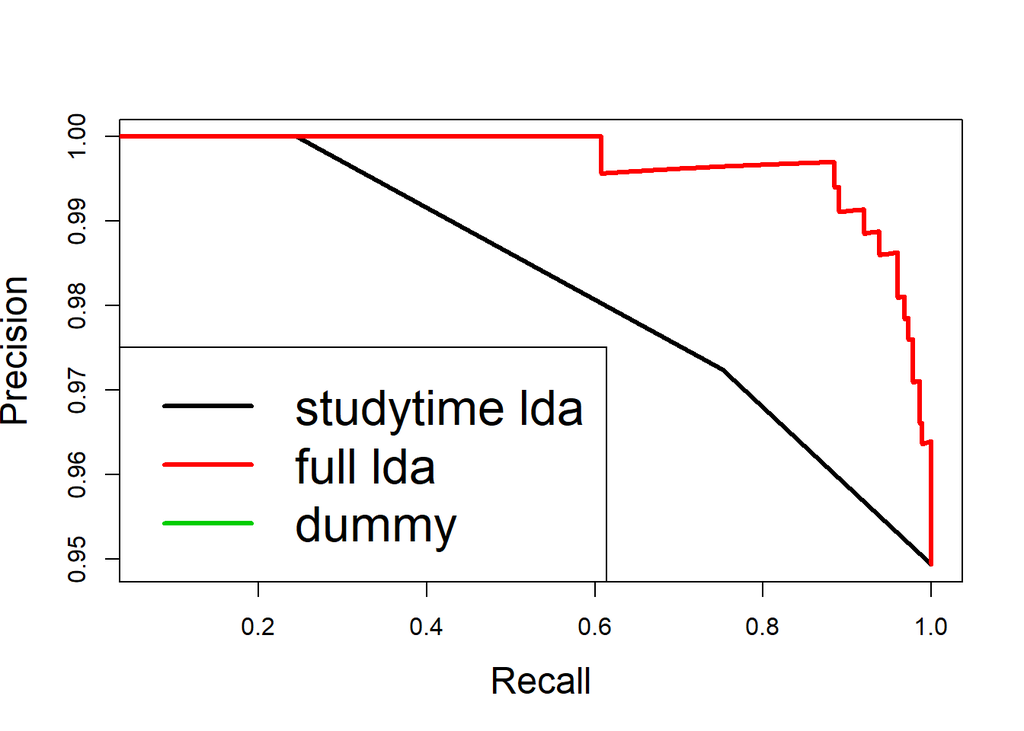

```r
library(caTools)
pr_objs <- lapply(pred_objs,
  performance, "prec", "rec")

for (i in seq(along=pr_objs)) {
  plot(pr_objs[[i]], add = i != 1, col=i,
       lwd=3, cex.lab=1.5)
}
legend("bottomleft",
       legend=paste(gsub("_", " ", names(pred_list))),
      col=1:3, lwd=3, cex=2)
```

So as our models precision is very high and good, it sacrifices recall. So in order to get accuracy, our model sacrifices relevance. And as we improve our models result’s relevance, we sacrifice the precision of our results.